# Exam 3

## Exam 3

#### Question

1. Camilo desea saber cuánto solución se necesita para llenar el cilindro interno, pero solamente cuenta con las medidas de las dimensiones que muestra la figura.

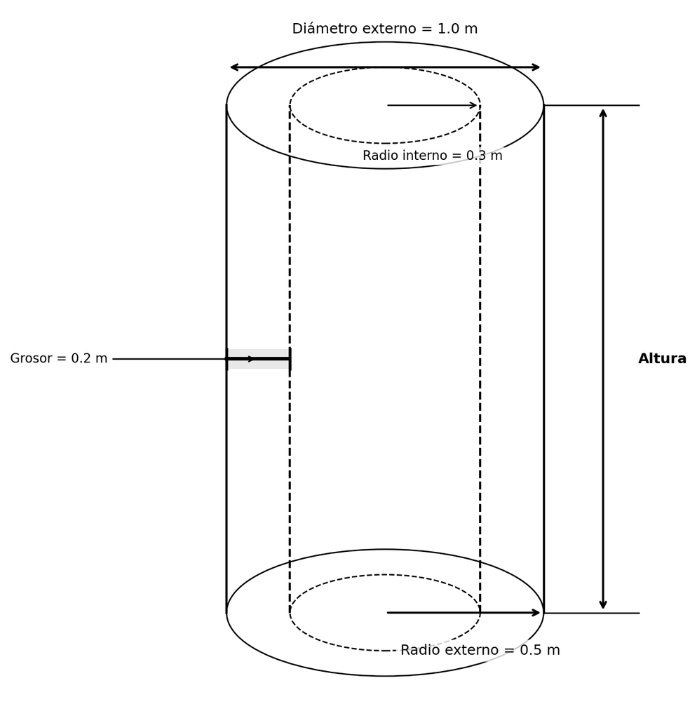

[figure not shown]

   ¿Cuál medida le falta a Camilo para hallar la cantidad deseada?
   1. Perímetro del cilindro.
   2. Radio externo.
   3. Diámetro externo.
   4. Altura del cilindro.

#### Solution

   La respuesta correcta es: **Altura del cilindro**.

   Para calcular el volumen de solución necesario para llenar el cilindro medio, necesitamos calcular el volumen de un cilindro, cuya fórmula es:

   $V = \pi \cdot r^2 \cdot h$

   Donde: - $r$ es el radio (en este caso, el radio interno = 0.3 m) - $h$ es la altura del cilindro

   Sin embargo, no se nos proporciona la altura del cilindro, que es esencial para calcular el volumen. Por lo tanto, a Camilo le falta conocer la altura del cilindro para poder calcular la cantidad de solución necesaria.

   Si tuviéramos la altura, el volumen se calcularía así: $V = \pi \cdot (0.3)^2 \cdot h = 0.28 \cdot h$ m³
   1. Falso
   2. Falso
   3. Falso
   4. Verdadero